# Processing of data comparing different SP3 solvent conditions

### Description

- MGF files were generated using RawQuant.
- The data were searched using SearchCLI and PeptideShakerCLI.
- Raw files were parsed for quantification data with RawQuant.

### Analysis

First call the libraries that are required.

```r
library(Biostrings)
library(Rmisc)
library(dplyr)
library(ggplot2)
library(RColorBrewer)
library(cowplot)
library(tidyr)
#library(reshape)
library(data.table)
library(UpSetR)
library(stringr)
library(Peptides)
library(VennDiagram)
library(limma)
```

First thing we want to do is compile the identifications data into a usable object for plotting. This involves taking the output from PeptideShaker and combining it with the RawQuant data. This is carried out using the code below.

First I will compile the identification data.

```r
id_files = list.files('/projects/ptx_analysis/chughes/projects-current/sp3-follow-up/high-low-mag-testing/reports-output', pattern='.*Default_PSM_Report.txt',full.names=TRUE) #psm files
quant_files = list.files('/projects/ptx_analysis/chughes/projects-current/sp3-follow-up/high-low-mag-testing/quant-output', pattern='.*QuantData.txt',full.names=TRUE) #ms2 quant files
```

Read in the identification data into a single data frame object.

```r
id_parsed = data.frame() #identification data storage object
#iterate over the identification files
for (i in 1:length(id_files)){
  psm_in = read.table(id_files[i],header=TRUE,sep='\t') #input file
  psm_f1 = psm_in %>%
    dplyr::select(Protein.s., Sequence, Spectrum.File, Spectrum.Title, m.z, Identification.Charge) %>% #select columns
    dplyr::mutate(Spectrum.Title, scan_num = sub(".*?spectrum (.*?)", "\\1", Spectrum.Title)) %>% #parse out the scan number
    dplyr::mutate(Identification.Charge, id_charge = gsub("[^0-9]", "", Identification.Charge)) %>% #parse out the charge
    dplyr::mutate(Spectrum.Title, fraction = sub(".*?hph_(.*?)_MGF\\.mgf", "\\1", Spectrum.File)) %>% #parse the fraction
    dplyr::select(Protein.s., Sequence, scan_num, m.z, id_charge, fraction) %>% #select new columns
    dplyr::mutate(Protein.s., first_accession = sapply(strsplit(as.character(Protein.s.),"\\,"), `[`, 1)) #parse the accession
  #adjust the column names
  colnames(psm_f1) = c('accession_groups','sequence','ScanNumber','id_precursor_mz','id_charge','fraction','accession')
  psm_f2 = dplyr::filter(psm_f1, !grepl('CONT_', accession_groups)) #remove the contaminant proteins
  id_parsed = rbind(id_parsed,psm_f2) #group the data with the previously processed set
}
```

Now we can process the rawquant data for the TMT values.

```r
quant_parsed = data.frame()
#iterate over the rawquant files
for (i in 1:length(quant_files)){
  quant_in = read.table(quant_files[i],header=TRUE,sep='\t') #grab the input file
  #change values that are zero to NA
  quant_in[,16:74][quant_in[,16:74] == 0] = NA
  #rearrange the data frame
  quant_meta = quant_in[,c('PrecursorMass','ScanNumber','MS1ScanNumber','RetentionTime',
                           'PrecursorCharge','MS2IonInjectionTime','MS1Interference',
                           'tmt126_mass','tmt127N_mass','tmt127C_mass','tmt128N_mass',
                           'tmt128C_mass','tmt129N_mass','tmt129C_mass','tmt130N_mass','tmt130C_mass',
                           'tmt131_mass')]
  quant_exprs = quant_in[,c('tmt126_intensity','tmt127N_intensity','tmt127C_intensity','tmt128N_intensity',
                            'tmt128C_intensity','tmt129N_intensity','tmt129C_intensity','tmt130N_intensity','tmt130C_intensity',
                            'tmt131_intensity','tmt126_noise','tmt127N_noise','tmt127C_noise','tmt128N_noise','tmt128C_noise',
                            'tmt129N_noise','tmt129C_noise','tmt130N_noise','tmt130C_noise','tmt131_noise')]
  #calculate signal to noise
  quant_sn = quant_exprs[,c(1:10)] / quant_exprs[,c(11:20)] #signal-to-noise calculation
  quant_sn$totalIntensity = rowSums(quant_exprs[,1:10],na.rm=TRUE) #total intensity calculation
  quant_sn$totalSN = rowSums(quant_sn[,1:10],na.rm=TRUE) #total signal-to-noise calculation
  quant_sn$totalNoise = rowSums(quant_exprs[,11:20],na.rm=TRUE) #total noise calculation
  quant_sn$totalNA = rowSums(is.na(quant_sn[,1:10])) #information about missing values
  quant_meta$fraction = sub(".*?hph_(.*?)_Q.*", "\\1", quant_files[i]) #add the fraction column
  quant_matrix = cbind(quant_meta,quant_sn) #bind the information and quantification together
  quant_parsed = rbind(quant_parsed, quant_matrix) #bind into a single frame
}
```

Now we can combine the two data sets together using a simple merge and save the data.

```r
id_quant = merge(id_parsed, quant_parsed, by=c('ScanNumber', 'fraction'))
saveRDS(id_quant, '/projects/ptx_analysis/chughes/projects-current/sp3-follow-up/high-low-mag-testing/Routput/ch_feb2018_SP3-high-low_id-quant-all.rds') #save the data
```

Now that I have the compiled data set, I want to plot how well the methods compare with one another. I can do this using their TMT intensities from rawquant.

```r
###first read in the data file I just prepared
psm_set = readRDS('/projects/ptx_analysis/chughes/projects-current/sp3-follow-up/high-low-mag-testing/Routput/ch_feb2018_SP3-high-low_id-quant-all.rds') #read processed data
```

First, lets just make a boxplot of the intensities across all peptides to look at global recovery.

Collapse redundant psm’s in the data.

```r
psm_agg <- setDT(psm_set)[, lapply(.SD,sum,na.rm=TRUE),by=.(sequence,fraction),.SDcols=c('tmt126_intensity','tmt127N_intensity','tmt127C_intensity','tmt128N_intensity',
                            'tmt128C_intensity','tmt129N_intensity','tmt129C_intensity','tmt130N_intensity','tmt130C_intensity')] #collapse by sequence and replicate
setDF(psm_agg) # convert back to dataframe
dim(psm_agg) #110867 rows are remaining
```

```
[1] 110867     11
```

Now plot the data in a boxplot.

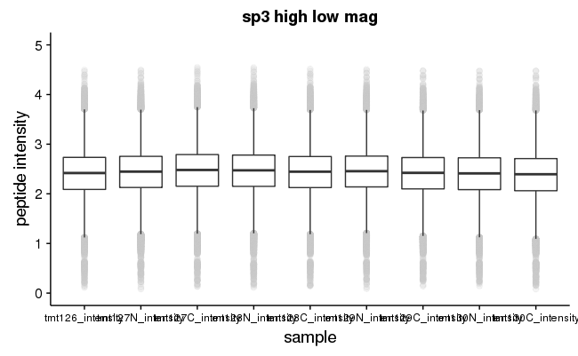

```r
peptides_melted = melt(psm_agg[,c(1,3:11)]) #melt the data to long format first
###now plot the data
highlow_plot = ggplot(peptides_melted, aes(variable, log10(value))) +
    #geom_point(aes(fill=variable),position=position_jitterdodge(dodge.width=0.9),colour='grey60',alpha=0.1) +
    geom_boxplot(position=position_dodge(width=0.9),outlier.colour='gray80', outlier.size = 2, outlier.alpha = 0.2) +
    labs(x = "sample", y = 'peptide intensity', title = 'sp3 high low mag') +
    theme(axis.text.x = element_text(size = 9)) +
    #scale_y_continuous(limits=c(0,1.5e9)) +
    theme(legend.position="none") +
    #scale_fill_manual(values=brewer.pal(6,"Set3")[c(1,3:4)]) +
    scale_y_continuous(limits = c(0,5), breaks = seq(0,5,1))
highlow_plot #call the plot
save_plot('/projects/ptx_analysis/chughes/projects-current/sp3-follow-up/high-low-mag-testing/Routput/ch_feb2018_SP3-high-low_peptide-boxplot.pdf',highlow_plot)
```

Now I want to look at identification overlap. For this I am going to filter the data based on a few criteria:

```r
##go back to the psm level data to filter
psm_filter1 = subset(psm_set, totalSN >= 100) #filter by signal to noise
psm_filter2 = subset(psm_filter1, totalNA <= 6) #filter by NA values
psm_filter2[, 24:32][psm_filter2[, 24:32] < 10] = NA #filter by signal to noise of individual channels

###now compile to peptides
psm_agg <- setDT(psm_set)[, lapply(.SD,sum,na.rm=TRUE),by=.(sequence),.SDcols=c('tmt126_intensity','tmt127N_intensity','tmt127C_intensity','tmt128N_intensity',
                            'tmt128C_intensity','tmt129N_intensity','tmt129C_intensity','tmt130N_intensity','tmt130C_intensity')] #collapse by sequence and replicate
setDF(psm_agg) # convert back to dataframe
dim(psm_agg) #110867 rows are remaining
```

```
[1] 87549    10
```

Now, if we want to calculate peptides identified by only one method, we need to assign a threshold. Let’s say that a peptide has to reach a signal to noise above 30 and have just 1 NA value across the 3 replicate channels in order to be considered identifed.

```r
###need to convert values less than 10 to NA again, it gets reset
psm_agg[, 2:10][psm_agg[, 2:10] < 10] = NA #convert to NA values
psm_agg$sp3_high_signal = rowSums(psm_agg[,c(2:4)], na.rm=TRUE) #sum the SP3 signal
psm_agg$sp3_high_nas = rowSums(is.na(psm_agg[,c(2:4)])) #count SP3 NA values
psm_agg$sp3_low_signal = rowSums(psm_agg[,c(5:7)], na.rm=TRUE) #sum the SP3 signal
psm_agg$sp3_low_nas = rowSums(is.na(psm_agg[,c(5:7)])) #count SP3 NA values
psm_agg$sp3_mag_signal = rowSums(psm_agg[,c(8:10)], na.rm=TRUE) #sum the SP3 signal
psm_agg$sp3_mag_nas = rowSums(is.na(psm_agg[,c(8:10)])) #count SP3 NA values
###now count the identifications
psm_agg$sp3_high_id = ifelse((psm_agg$sp3_high_signal >= 30) & (psm_agg$sp3_high_nas <= 1), TRUE, FALSE)
psm_agg$sp3_low_id = ifelse((psm_agg$sp3_low_signal >= 30) & (psm_agg$sp3_low_nas <= 1), TRUE, FALSE)
psm_agg$sp3_mag_id = ifelse((psm_agg$sp3_mag_signal >= 30) & (psm_agg$sp3_mag_nas <= 1), TRUE, FALSE)
##get the specific data sets out for comparison by upset
sp3_high_set = psm_agg[psm_agg$sp3_high_id == TRUE, ]
sp3_low_set = psm_agg[psm_agg$sp3_low_id == TRUE, ]
sp3_mag_set = psm_agg[psm_agg$sp3_mag_id == TRUE, ]
```

Now plot the data in an Upset.

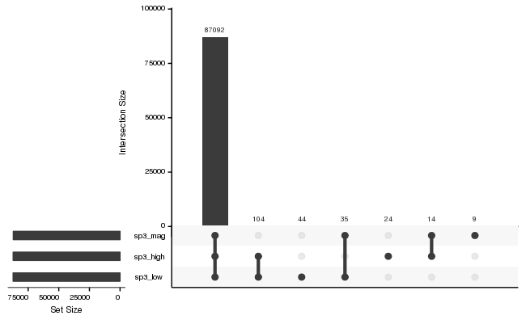

```r
#set the inputs
peptide_input <- list(sp3_high = as.character(sp3_high_set$sequence),
                      sp3_low = as.character(sp3_low_set$sequence),
                      sp3_mag = as.character(sp3_mag_set$sequence))
#now make the plot
#pdf('/projects/ptx_analysis/chughes/projects-current/sp3-follow-up/high-low-mag-testing/Routput/ch_feb2018_SP3-high-low_peptide-upset.pdf')
upset(fromList(peptide_input),
      order.by = "freq",
      point.size = 2.5,
      line.size = 1.5)
```

```r
#dev.off()
```

Take a quick look at missed cleavages before we move on.

```r
###use the aggregated peptide data for this
###look for missed cleavages
psm_agg$sub_sequence = str_sub(psm_agg$sequence,1,nchar(as.character(psm_agg$sequence)) - 1) #trim the final amino acid
psm_agg$missed = str_count(psm_agg$sub_sequence,'[RK]') #count the number of internal K or R
###output the data values
table(psm_agg$missed) / length(psm_agg$missed)
```

```
           0            1            2            3            4            5            6            7            8            9
8.600898e-01 1.298359e-01 9.560360e-03 3.655096e-04 1.142218e-05 1.142218e-05 3.426653e-05 4.568870e-05 2.284435e-05 2.284435e-05
```

```r
###first filter the data using the same parameters as above
psm_filter1 = subset(psm_set, totalSN >= 100) #filter by signal to noise
psm_filter2 = subset(psm_filter1, totalNA <= 6) #filter by NA values
psm_filter2[, 24:32][psm_filter2[, 24:32] < 10] = NA #filter by signal to noise of individual channels
psm_filter2$number.of.peptides = 1 #add a peptide counter
###now compile to peptides
pro_agg <- setDT(psm_filter2)[, lapply(.SD,sum,na.rm=TRUE),by=.(accession),.SDcols=c('number.of.peptides','tmt126_intensity','tmt127N_intensity','tmt127C_intensity','tmt128N_intensity',
                            'tmt128C_intensity','tmt129N_intensity','tmt129C_intensity','tmt130N_intensity','tmt130C_intensity')] #collapse by accession number
setDF(pro_agg) # convert back to dataframe
pro_set = subset(pro_agg, number.of.peptides > 1) #remove single peptide hits
dim(pro_set) #7696 rows are remaining
```

```
[1] 7696   11
```

Now I can get the protein overlap information.

```r
###need to convert values less than 10 to NA again, it gets reset
pro_set[, 3:11][pro_set[, 3:11] < 10] = NA #convert to NA values
pro_set$sp3_high_signal = rowSums(pro_set[,c(3:5)], na.rm=TRUE) #sum the SP3 signal
pro_set$sp3_high_nas = rowSums(is.na(pro_set[,c(3:5)])) #count SP3 NA values
pro_set$sp3_low_signal = rowSums(pro_set[,c(6:8)], na.rm=TRUE) #sum the SP3 signal
pro_set$sp3_low_nas = rowSums(is.na(pro_set[,c(6:8)])) #count SP3 NA values
pro_set$sp3_mag_signal = rowSums(pro_set[,c(9:11)], na.rm=TRUE) #sum the SP3 signal
pro_set$sp3_mag_nas = rowSums(is.na(pro_set[,c(9:11)])) #count SP3 NA values
###now count the identifications
pro_set$sp3_high_id = ifelse((pro_set$sp3_high_signal >= 30) & (pro_set$sp3_high_nas <= 1), TRUE, FALSE)
pro_set$sp3_low_id = ifelse((pro_set$sp3_low_signal >= 30) & (pro_set$sp3_low_nas <= 1), TRUE, FALSE)
pro_set$sp3_mag_id = ifelse((pro_set$sp3_mag_signal >= 30) & (pro_set$sp3_mag_nas <= 1), TRUE, FALSE)
##get the specific data sets out for comparison by upset
sp3_high_set = pro_set[pro_set$sp3_high_id == TRUE, ]
sp3_low_set = pro_set[pro_set$sp3_low_id == TRUE, ]
sp3_mag_set = pro_set[pro_set$sp3_mag_id == TRUE, ]
```

Now plot the data in an Upset.

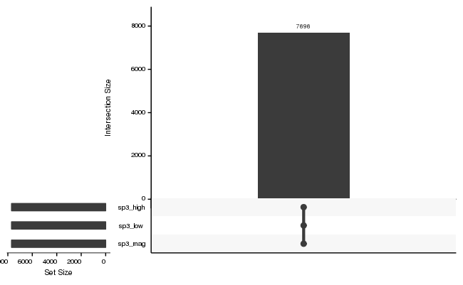

```r
#set the inputs
protein_input <- list(sp3_high = as.character(sp3_high_set$accession),
                      sp3_low = as.character(sp3_low_set$accession),
                      sp3_mag = as.character(sp3_mag_set$accession))
#now make the plot
#pdf('/projects/ptx_analysis/chughes/projects-current/sp3-follow-up/high-low-mag-testing/Routput/ch_feb2018_SP3-high-low_protein-upset.pdf')
upset(fromList(protein_input),
      order.by = "freq",
      point.size = 2.5,
      line.size = 1.5)
```

```r
#dev.off()
```

```r
#do some basic normalization
summary(pro_set[,3:11]) #look at the data to investigate normalization
```

```
 tmt126_intensity    tmt127N_intensity   tmt127C_intensity   tmt128N_intensity   tmt128C_intensity   tmt129N_intensity   tmt129C_intensity   tmt130N_intensity   tmt130C_intensity
 Min.   :    11.94   Min.   :    25.59   Min.   :    14.01   Min.   :    21.67   Min.   :    28.07   Min.   :    14.82   Min.   :    30.84   Min.   :    25.23   Min.   :    11.0
 1st Qu.:   859.89   1st Qu.:   921.27   1st Qu.:   991.60   1st Qu.:   967.06   1st Qu.:   903.40   1st Qu.:   926.86   1st Qu.:   855.91   1st Qu.:   838.23   1st Qu.:   798.5
 Median :  2438.79   Median :  2584.83   Median :  2810.88   Median :  2730.02   Median :  2542.54   Median :  2596.59   Median :  2438.87   Median :  2406.66   Median :  2298.8
 Mean   :  6512.67   Mean   :  6823.71   Mean   :  7408.52   Mean   :  7253.80   Mean   :  6747.88   Mean   :  6892.90   Mean   :  6444.92   Mean   :  6384.74   Mean   :  6140.8
 3rd Qu.:  6667.19   3rd Qu.:  7024.27   3rd Qu.:  7611.22   3rd Qu.:  7428.12   3rd Qu.:  6924.73   3rd Qu.:  7099.08   3rd Qu.:  6600.94   3rd Qu.:  6578.51   3rd Qu.:  6302.2
 Max.   :225596.62   Max.   :234875.26   Max.   :258305.31   Max.   :250773.86   Max.   :236963.71   Max.   :240557.98   Max.   :218335.96   Max.   :216705.74   Max.   :208105.4
```

```r
signal_sums = colSums(pro_set[,3:11],na.rm=TRUE) #sum the signals across all channels and store
#now loop over each of the columns taking the the proportion of the ion signal relative to the total multiplied by the median of all totals
for (l in 3:11){
        total_intensity = sum(pro_set[,l],na.rm=TRUE)
        pro_set[,l] = (pro_set[,l] / total_intensity) * median(signal_sums)
}
summary(pro_set[,3:11]) #look at the summary again...looks good after normalization
```

```
 tmt126_intensity    tmt127N_intensity   tmt127C_intensity   tmt128N_intensity   tmt128C_intensity   tmt129N_intensity   tmt129C_intensity   tmt130N_intensity   tmt130C_intensity
 Min.   :    12.37   Min.   :    25.31   Min.   :    12.76   Min.   :    20.16   Min.   :    28.07   Min.   :    14.51   Min.   :    32.29   Min.   :    26.67   Min.   :    12.09
 1st Qu.:   890.94   1st Qu.:   911.04   1st Qu.:   903.18   1st Qu.:   899.61   1st Qu.:   903.40   1st Qu.:   907.36   1st Qu.:   896.14   1st Qu.:   885.90   1st Qu.:   877.40
 Median :  2526.87   Median :  2556.11   Median :  2560.23   Median :  2539.61   Median :  2542.54   Median :  2541.96   Median :  2553.52   Median :  2543.54   Median :  2526.09
 Mean   :  6747.88   Mean   :  6747.88   Mean   :  6747.88   Mean   :  6747.88   Mean   :  6747.88   Mean   :  6747.88   Mean   :  6747.88   Mean   :  6747.88   Mean   :  6747.88
 3rd Qu.:  6907.98   3rd Qu.:  6946.21   3rd Qu.:  6932.50   3rd Qu.:  6910.04   3rd Qu.:  6924.73   3rd Qu.:  6949.72   3rd Qu.:  6911.23   3rd Qu.:  6952.66   3rd Qu.:  6925.24
 Max.   :233744.09   Max.   :232264.99   Max.   :235271.45   Max.   :233283.43   Max.   :236963.71   Max.   :235496.75   Max.   :228599.43   Max.   :229031.00   Max.   :228680.41
```

Now we can perform the differential expression analysis with limma. First lets compare high vs low.

```r
#calculate differential expression using limma
eset = as.matrix(log2(pro_set[,c(3:8)])) #log transform the expression data and transfer to a new object
design <- cbind(HIGH=c(1,1,1,0,0,0),LOW=c(0,0,0,1,1,1)) #create the design matrix
fit <- lmFit(eset,design) #calculate the linear model of the expression values
cont.matrix <- makeContrasts(HIGHvsLOW=HIGH-LOW, levels=design) #create the contrasts matrix
fit2 <- contrasts.fit(fit, cont.matrix) #calculate the contrasts
fit2 <- eBayes(fit2) #empirical Bayes smoothing
logFC = fit2$coef #extract fold changes
pVal = fit2$p.value #extract p-values
p.adj = p.adjust(fit2$p.value, method="BH") #apply multiple testing correction to the p-values
#insert the data back into the original matrix
pro_set$logFC <- logFC
pro_set$p.value <- pVal
pro_set$p.adj.value <- p.adj
pro_ordered = pro_set[order(-pro_set$logFC),] #reorder the matrix by fold change
saveRDS(pro_ordered, '/projects/ptx_analysis/chughes/projects-current/sp3-follow-up/high-low-mag-testing/Routput/ch_feb2018_SP3-high-low_highVSlow.rds') #save the data
write.table(pro_ordered, '/projects/ptx_analysis/chughes/projects-current/sp3-follow-up/high-low-mag-testing/Routput/ch_feb2018_SP3-high-low_highVSlow-proteins.txt', sep = '\t', row.names = FALSE, col.names = TRUE, quote = FALSE)
```

Now do high vs mag.

```r
#calculate differential expression using limma
eset = as.matrix(log2(pro_set[,c(3:5,9:11)])) #log transform the expression data and transfer to a new object
design <- cbind(HIGH=c(1,1,1,0,0,0),MAG=c(0,0,0,1,1,1)) #create the design matrix
fit <- lmFit(eset,design) #calculate the linear model of the expression values
cont.matrix <- makeContrasts(HIGHvsMAG=HIGH-MAG, levels=design) #create the contrasts matrix
fit2 <- contrasts.fit(fit, cont.matrix) #calculate the contrasts
fit2 <- eBayes(fit2) #empirical Bayes smoothing
logFC = fit2$coef #extract fold changes
pVal = fit2$p.value #extract p-values
p.adj = p.adjust(fit2$p.value, method="BH") #apply multiple testing correction to the p-values
#insert the data back into the original matrix
pro_set$logFC <- logFC
pro_set$p.value <- pVal
pro_set$p.adj.value <- p.adj
pro_ordered = pro_set[order(-pro_set$logFC),] #reorder the matrix by fold change
saveRDS(pro_ordered, '/projects/ptx_analysis/chughes/projects-current/sp3-follow-up/high-low-mag-testing/Routput/ch_feb2018_SP3-high-low_highVSmag.rds') #save the data
```

And lastly, low vs mag.

```r
#calculate differential expression using limma
eset = as.matrix(log2(pro_set[,c(6:11)])) #log transform the expression data and transfer to a new object
design <- cbind(LOW=c(1,1,1,0,0,0),MAG=c(0,0,0,1,1,1)) #create the design matrix
fit <- lmFit(eset,design) #calculate the linear model of the expression values
cont.matrix <- makeContrasts(LOWvsMAG=LOW-MAG, levels=design) #create the contrasts matrix
fit2 <- contrasts.fit(fit, cont.matrix) #calculate the contrasts
fit2 <- eBayes(fit2) #empirical Bayes smoothing
logFC = fit2$coef #extract fold changes
pVal = fit2$p.value #extract p-values
p.adj = p.adjust(fit2$p.value, method="BH") #apply multiple testing correction to the p-values
#insert the data back into the original matrix
pro_set$logFC <- logFC
pro_set$p.value <- pVal
pro_set$p.adj.value <- p.adj
pro_ordered = pro_set[order(-pro_set$logFC),] #reorder the matrix by fold change
saveRDS(pro_ordered, '/projects/ptx_analysis/chughes/projects-current/sp3-follow-up/high-low-mag-testing/Routput/ch_feb2018_SP3-high-low_lowVSmag.rds') #save the data
```

Now we can plot the differential expression, for visualization purposes.

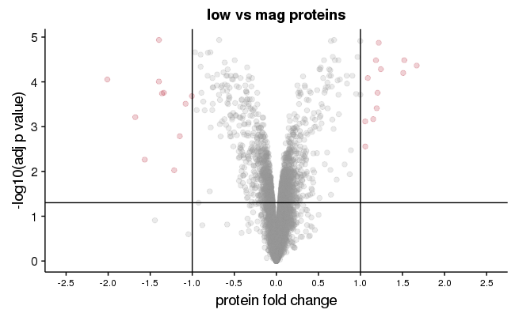

```r
###change your input in the next command to file you desire.
pro_ordered = readRDS('/projects/ptx_analysis/chughes/projects-current/sp3-follow-up/high-low-mag-testing/Routput/ch_feb2018_SP3-high-low_lowVSmag.rds')
#add a threshold for coloring signicant points
pro_ordered$threshold = as.factor((pro_ordered$p.adj.value < 0.05) & (pro_ordered$logFC < -1) | (pro_ordered$p.adj.value < 0.05) & (pro_ordered$logFC > 1)) #assign the threshold
#make the plot
sp3_scatter = ggplot(pro_ordered, aes(logFC, -log10(p.adj.value), color = threshold)) +
    geom_point(alpha=0.2,size=2) +
    labs(x = "protein fold change", y = '-log10(adj p value)', title = 'low vs mag proteins') +
    theme(axis.text.x = element_text(size = 9)) +
    #scale_y_continuous(limits=c(0,1.5e9)) +
    geom_hline(yintercept = -log10(0.05)) +
    geom_vline(xintercept = 1) +
    geom_vline(xintercept = -1) +
    scale_color_manual(values=c('gray60',brewer.pal(6,"RdBu")[1])) +
    scale_x_continuous(limits = c(-2.5,2.5), breaks = seq(-4,4,0.5)) +
    theme(legend.position="none")
sp3_scatter #call the plot
save_plot('/projects/ptx_analysis/chughes/projects-current/sp3-follow-up/high-low-mag-testing/Routput/ch_feb2018_SP3-high-low_lowVSmag-volcano.pdf',sp3_scatter)
```

```r
#get the values
table((pro_ordered$p.adj.value < 0.05) & (pro_ordered$logFC < -1))
```

```
FALSE  TRUE
 7685    11
```

```r
table((pro_ordered$p.adj.value < 0.05) & (pro_ordered$logFC > 1))
```

```
FALSE  TRUE
 7684    12
```

Interesting. The methods are almost identical.